## Zu „Don Quichotte“ von Jules Massenet

# Die Abenteuer eines träumenden Ritters

## Er kämpft gegen Windmühlen und für eine große Liebe: Don Quichotte jagt ab 30. Mai seinen Träumen und Fantastereien hinterher. Jules Massenet hat ihm mit einer heiter-melancholischen Oper ein musikalisches Denkmal gesetzt.

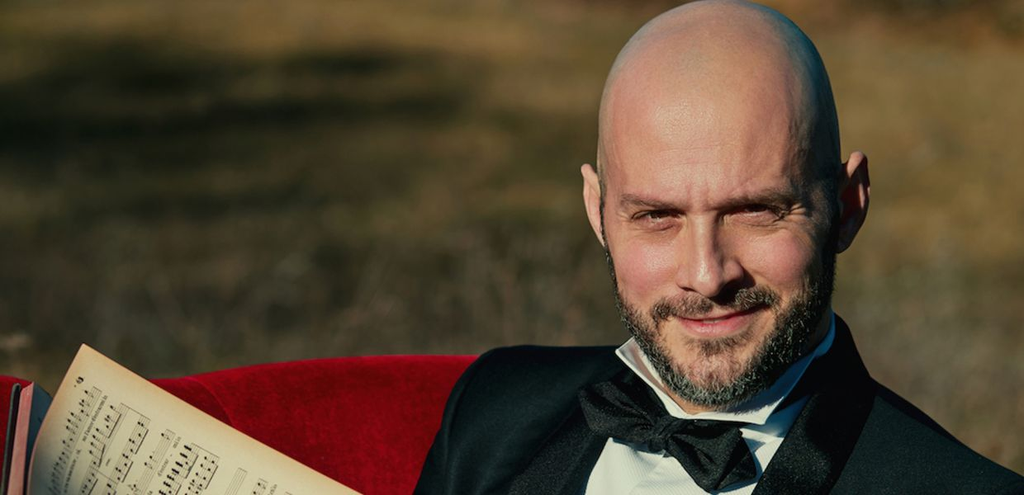

[zurück](https://deutscheoperberlin.de/de_DE/blog)

[Don Quichotte](https://deutscheoperberlin.de/de_DE/calendar/don-quichotte.15148333)

Comédie héroique von Jules Massenet  
Musikalische Leitung: Emmanuel Villaume  
Inszenierung: Jakop Ahlbom  
Mit Alex Esposito, Seth Carico, Clémentine Margaine u. a.

[Premiere am 30. Mai 2019](https://deutscheoperberlin.de/de_DE/calendar/don-quichotte.15148333)

Als im Jahr 2002 das Osloer Nobelinstitut 100 Schriftsteller aus aller Welt nach dem „besten Buch der Welt“ und aller Zeiten befragten, da gewann mit großem Abstand: „Don Quijote“ – ein über 1000 Seiten starker Roman, vor vierhundert Jahren erdacht von einem Autor, der lange Zeit alles war, nur nicht ein erfolgreicher Literat. Miguel de Cervantes kam 1547 unweit von Madrid zur Welt. Er studierte Theologie, kämpfte in Seeschlachten, wurde verwundet, von Seeräubern gefangengenommen und als Sklave nach Algerien verschleppt. Als er Jahre später freigekauft wurde, versuchte er sich als Autor, ohne Erfolg. Alles änderte sich erst, als er den „Don Quijote“ herausbrachte. Der Roman erschien in zwei Bänden 1605 und 1615 und eroberte im Flug die ganze Welt. Inzwischen zählt man über 2.000 Auflagen weltweit sowie Bühnenstücke, Opern, Filme und vieles mehr. Jedes Kind scheint ihn zu kennen, doch: Wer ist dieser Windmühlen-Kämpfer und was macht seine Geschichte seit Jahrhunderten zum Bestseller?

Don Quijote – so weiß es der Romanerzähler – verschlingt Ritterromane in so großer Zahl, dass sein Gehirn vom vielen Lesen „austrocknet“ und er schließlich den Verstand verliert: „Sein Kopf füllte sich mit allem, was er in den Büchern gelesen, mit Verzauberungen, Schlachten, Liebe und sonstigem haarsträubenden Unsinn.“ Derart in das goldene Zeitalter des Ritterwesens eingetaucht, stürzt sich Quijote unter Einsatz von Leib und Leben in Abenteuer, die ihm seine Fantasie von nun an gebietet. Mit blitzender Ritterrüstung, Lanze, Schild und Schwert prescht er auf einem alten Pferd voran, um heldenhaft gegen das Unrecht zu kämpfen und den Menschen die alten glückseligen Zeiten wiederzubringen. Miguel de Cervantes gelingt mit Don Quijote das Porträt eines Mannes, der die Wirklichkeit ausschließlich durch die Brille einer ritterlichen Weltsicht betrachtet und seine Träume in die Tat umsetzt. Das macht diese Figur so außerordentlich: Don Quijote stellt sich die Welt nicht anders und besser vor, er lebt sie anders. Ob man ihn Spinner oder Fantasten nennt: Sein Mut und sein unerschütterlicher Glaube an die eigene Mission faszinieren.

Als der französische Komponist Jules Massenet zu Beginn des 20. Jahrhunderts nach dem Stoff greift, setzt er für seine „Quichotte“-Oper eigene Akzente: der träumende Ritter als ein närrischer alternder Mann, der sich in die jugendlich-schöne Dulcinée verliebt. Mit der ihm ganz eigenen sinnlich-eleganten Musiksprache versetzt Massenet den spanischen Ritter in die Gefühlswelt der Pariser Jahrhundertwende. Sein Libretto orientiert sich weniger am originalen spanischen Roman als vielmehr an einem in Paris erfolgreichen Bühnenstück, das – ganz im Geschmack des Fin de Siècle – die angebetete Frau nicht wie bei Cervantes als Bauerntrampel, sondern als mondäne Kurtisane zeichnet. Massenets Oper könnte auch „Don Quichotte und Dulcinée“ heißen, denn das Verhältnis zur umworbenen Frau ist Motor der gesamten Handlung: Um Dulcinées Liebe zu erringen, soll Don Quichotte ein von Räubern gestohlenes Collier zurückbringen. Als der Liebesritter tatsächlich in die Hände der Banditen fällt, sind jene von Quichottes Großmut und naiver Gutartigkeit so berührt, dass sie ihm Leib, Leben und obendrein den geraubten Schmuck schenken. Der zurückkehrende Sieger wagt einen Heiratsantrag, aber die Herzensdame lacht nur. Der alte Träumer, er ist am Ende und stirbt. Seinem treuen Begleiter Sancho Pansa möchte er als letzte Tat noch etwas vererben, doch sein einziger Besitz sind seine Träume.

Auch für den Komponisten selbst war dieser „Don Quichotte“ ein Vermächtnis. Von Krankheit gezeichnet, konnte Massenet die Partitur nur im Bett liegend vollenden. Des Komponisten eigene Auseinandersetzung mit Abschied und Tod spiegelt sich in Don Quichottes Suche nach der Möglichkeit eines glückhaften Lebens, wo Träume Realität werden. Die Oper wurde Jules Massenets letzter künstlerischer Triumph. Auf die Uraufführung in Monte Carlo 1910 folgten schnell viele Premieren in Europa. Die letzte Neuinszenierung in Berlin war vor knapp 50 Jahren: höchste Zeit, mit dem heroischen und komischen „Ritter von der traurigen Gestalt“ auf einer Berliner Opernbühne wieder zu träumen.

Für die Neuproduktion an der Deutschen Oper Berlin sind mit Alex Esposito (Don Quichotte, auf dem Foto oben) und Clémentine Margaine (Dulcinée) zwei Weltklasse-Sänger der jüngeren Generation besetzt. Es inszeniert Jakop Ahlbom, der mit seinen Produktionen magische und surrealistisch-albtraumhafte Theaterwelten schafft und damit europaweit auf Tour geht.

Verwandte Themen

[Don Quichotte](https://deutscheoperberlin.de/de_DE/blog?tag=Don%20Quichotte)

[Französische Oper](https://deutscheoperberlin.de/de_DE/blog?tag=Franz%C3%B6sische%20Oper)